# P4_ADacko

Aleksandra Dacko

10/3/2022

```r
library(ISLR)
library(MASS)
library(tidyverse)
library(magrittr)
```

# Regression in R

```r
some_formula <- outcome ~ predictor_1 + predictor_2
class(some_formula)
```

```
## [1] "formula"
```

```r
as.character(some_formula)
```

```
## [1] "~"                         "outcome"
## [3] "predictor_1 + predictor_2"
```

```r
summary(Boston)
```

```
##       crim                zn             indus            chas
##  Min.   : 0.00632   Min.   :  0.00   Min.   : 0.46   Min.   :0.00000
##  1st Qu.: 0.08205   1st Qu.:  0.00   1st Qu.: 5.19   1st Qu.:0.00000
##  Median : 0.25651   Median :  0.00   Median : 9.69   Median :0.00000
##  Mean   : 3.61352   Mean   : 11.36   Mean   :11.14   Mean   :0.06917
##  3rd Qu.: 3.67708   3rd Qu.: 12.50   3rd Qu.:18.10   3rd Qu.:0.00000
##  Max.   :88.97620   Max.   :100.00   Max.   :27.74   Max.   :1.00000
##       nox               rm             age              dis
##  Min.   :0.3850   Min.   :3.561   Min.   :  2.90   Min.   : 1.130
##  1st Qu.:0.4490   1st Qu.:5.886   1st Qu.: 45.02   1st Qu.: 2.100
##  Median :0.5380   Median :6.208   Median : 77.50   Median : 3.207
##  Mean   :0.5547   Mean   :6.285   Mean   : 68.57   Mean   : 3.795
##  3rd Qu.:0.6240   3rd Qu.:6.623   3rd Qu.: 94.08   3rd Qu.: 5.188
##  Max.   :0.8710   Max.   :8.780   Max.   :100.00   Max.   :12.127
##       rad              tax           ptratio          black
##  Min.   : 1.000   Min.   :187.0   Min.   :12.60   Min.   :  0.32
##  1st Qu.: 4.000   1st Qu.:279.0   1st Qu.:17.40   1st Qu.:375.38
##  Median : 5.000   Median :330.0   Median :19.05   Median :391.44
##  Mean   : 9.549   Mean   :408.2   Mean   :18.46   Mean   :356.67
##  3rd Qu.:24.000   3rd Qu.:666.0   3rd Qu.:20.20   3rd Qu.:396.23
##  Max.   :24.000   Max.   :711.0   Max.   :22.00   Max.   :396.90
##      lstat            medv
##  Min.   : 1.73   Min.   : 5.00
##  1st Qu.: 6.95   1st Qu.:17.02
##  Median :11.36   Median :21.20
##  Mean   :12.65   Mean   :22.53
##  3rd Qu.:16.95   3rd Qu.:25.00
##  Max.   :37.97   Max.   :50.00
```

```r
some_formula[2]
```

```
## outcome()
```

### 1. Create a linear model object called lm_ses using the formula medv ~ lstat and the Boston dataset.

```r
lm_ses<-lm(data=Boston,medv~lstat)
```

### 2. Use the function coef() to extract the intercept and slope from the lm_ses object. Interpret the slope coefficient.

```r
lm_ses %>% coef()
```

```
## (Intercept)       lstat
##  34.5538409  -0.9500494
```

The housing value (`medv`) is equal to on average 34.55 when `lstat` is held 0. With one point rise in `lstat` the housing value (`medv`) is going to decrease of about 0.95.

### 3.Use summary() to get a summary of the lm_ses object. What do you see? You can use the help file ?summary.lm.

```r
lm_ses %>%  summary()
```

```
##
## Call:
## lm(formula = medv ~ lstat, data = Boston)
##
## Residuals:
##     Min      1Q  Median      3Q     Max
## -15.168  -3.990  -1.318   2.034  24.500
##
## Coefficients:
##             Estimate Std. Error t value Pr(>|t|)
## (Intercept) 34.55384    0.56263   61.41   <2e-16 ***
## lstat       -0.95005    0.03873  -24.53   <2e-16 ***
## ---
## Signif. codes:  0 '***' 0.001 '**' 0.01 '*' 0.05 '.' 0.1 ' ' 1
##
## Residual standard error: 6.216 on 504 degrees of freedom
## Multiple R-squared:  0.5441, Adjusted R-squared:  0.5432
## F-statistic: 601.6 on 1 and 504 DF,  p-value: < 2.2e-16
```

We can see the following in the output:

- coefficients: a named vector of coefficients
- residuals: the residuals, that is response minus fitted values.
- fitted.values: the fitted mean values.
- df.residual: the residual degrees of freedom.

### 4. Save the predicted y values to a variable called y_pred

```r
y_pred<-lm_ses %>% predict()
```

### 5.Create a scatter plot with y_pred mapped to the x position and the true y value (Boston$medv) mapped to the y value. What do you see? What would this plot look like if the fit were perfect?

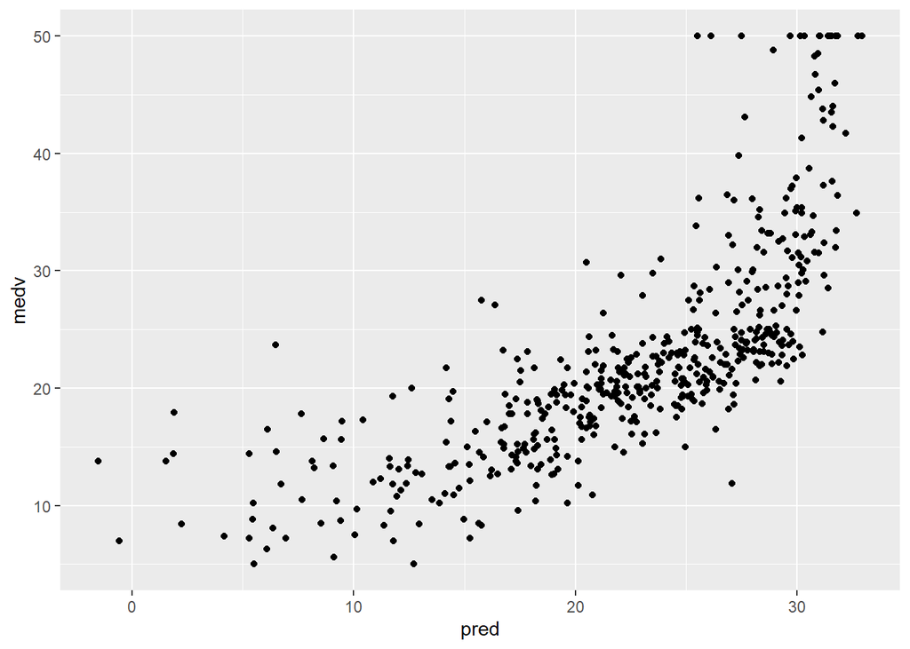

```r
data.frame(medv=Boston$medv,pred=y_pred) %>% ggplot(aes(x=pred,y=medv)) + geom_point()
```

### 6.Use the seq() function to generate a sequence of 1000 equally spaced values from 0 to 40. Store this vector in a data frame with (data.frame() or tibble()) as its column name lstat. Name the data frame pred_dat.

```r
pred_dat<-data.frame(lstat=seq(length.out=1000,from=0,to=40))
```

### 7.Use the newly created data frame as the newdata argument to a predict() call for lm_ses. Store it in a variable named y_pred_new

```r
y_pred_new<- predict(lm_ses, newdata = pred_dat)
```

# Plotting lm() in ggplot

### 8.Create a scatter plot from the Boston dataset with lstat mapped to the x position and medv mapped to the y position. Store the plot in an object called p_scatter.

```r
p_scatter<-Boston %>% ggplot(aes(y=medv,x=lstat))+geom_point()+theme_minimal()
```

### 9. Add the vector y_pred_new to the pred_dat data frame with the name medv

```r
pred_dat %<>% mutate(medv=y_pred_new)
```

### 10. Add a geom_line() to p_scatter, with pred_dat as the data argument. What does this line represent?

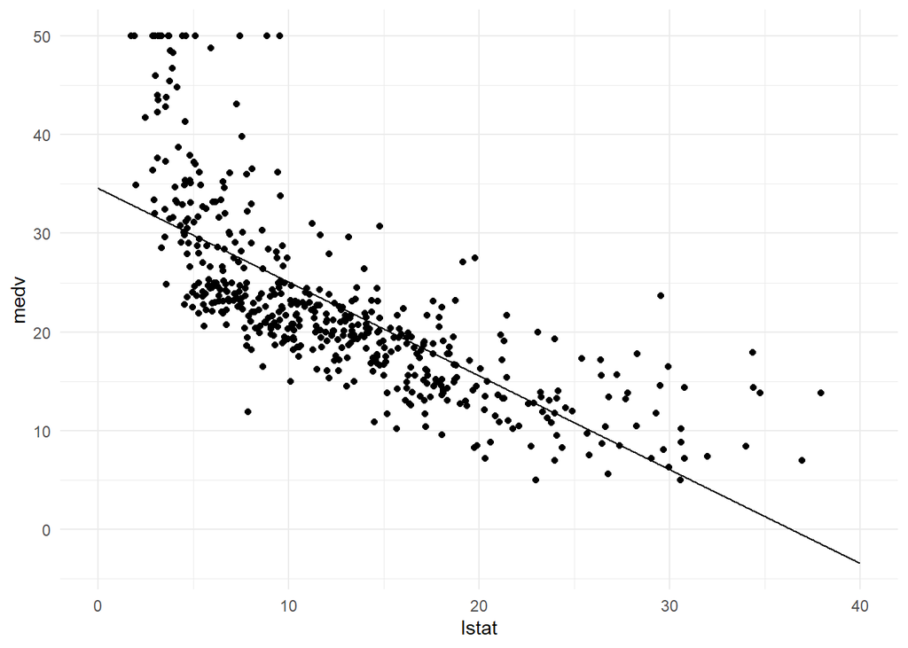

```r
p_scatter+geom_line(data=pred_dat)
```

The points represents the true data while the line is a linear regression approximation of the data.

### 11. The interval argument can be used to generate confidence or prediction intervals. Create a new object called y_pred_95 using predict() (again with the pred_dat data) with the interval argument set to “confidence”. What is in this object?

```r
y_pred_95<-predict(lm_ses,data.frame(lstat=seq(length.out=1000,from=0,to=40)),interval = "confidence")
y_pred_95<-as.data.frame(y_pred_95)
```

### 12.Create a data frame with 4 columns: medv, lstat, lower, and upper.

```r
pred_dat_95<-data.frame(medv=y_pred_95$fit,lstat=seq(length.out=1000,from=0,to=40),lower=y_pred_95$lwr,upper=y_pred_95$upr)

head(pred_dat_95)
```

```
##       medv      lstat    lower    upper
## 1 34.55384 0.00000000 33.44846 35.65922
## 2 34.51580 0.04004004 33.41307 35.61853
## 3 34.47776 0.08008008 33.37768 35.57784
## 4 34.43972 0.12012012 33.34229 35.53715
## 5 34.40168 0.16016016 33.30690 35.49646
## 6 34.36364 0.20020020 33.27150 35.45578
```

### 13.Add a geom_ribbon() to the plot with the data frame you just made. The ribbon geom requires three aesthetics: x (lstat, already mapped), ymin (lower), and ymax (upper). Add the ribbon below the geom_line() and the geom_points() of before to make sure those remain visible. Give it a nice colour and clean up the plot, too!

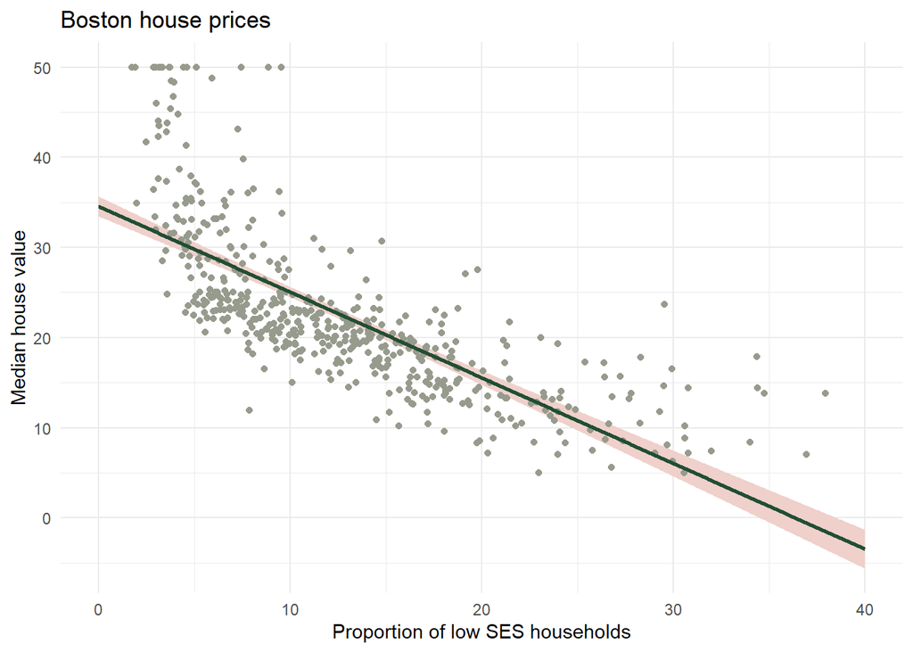

```r
Boston %>% ggplot(aes(y=medv,x=lstat))+geom_ribbon(aes(ymin=lower,ymax=upper),data=pred_dat_95,fill="#EFD0CA")+geom_point(colour="#979B8D")+geom_line(data = pred_dat,colour="#214E34",size=1)+theme_minimal()+labs(x    = "Proportion of low SES households",
       y    = "Median house value",
       title = "Boston house prices")
```

### 14.Explain in your own words what the ribbon represents.

The ribbon represents the 95% confidence interval of the fit line. The uncertainty in the estimates of the coefficients are taken into account with this ribbon.

### 15.Do the same thing, but now with the prediction interval instead of the confidence interval.

```r
y_pred_int_95<-predict(lm_ses,data.frame(lstat=seq(length.out=1000,from=0,to=40)),interval = "prediction")
y_pred_int_95<-as.data.frame(y_pred_int_95)
head(y_pred_int_95)
```

```
##        fit      lwr      upr
## 1 34.55384 22.29192 46.81576
## 2 34.51580 22.25412 46.77748
## 3 34.47776 22.21632 46.73920
## 4 34.43972 22.17852 46.70092
## 5 34.40168 22.14071 46.66265
## 6 34.36364 22.10291 46.62437
```

```r
pred_int_95<-data.frame(medv=y_pred_int_95$fit,lstat=seq(length.out=1000,from=0,to=40),lower=y_pred_int_95$lwr,upper=y_pred_int_95$upr)

head(pred_int_95)
```

```
##       medv      lstat    lower    upper
## 1 34.55384 0.00000000 22.29192 46.81576
## 2 34.51580 0.04004004 22.25412 46.77748
## 3 34.47776 0.08008008 22.21632 46.73920
## 4 34.43972 0.12012012 22.17852 46.70092
## 5 34.40168 0.16016016 22.14071 46.66265
## 6 34.36364 0.20020020 22.10291 46.62437
```

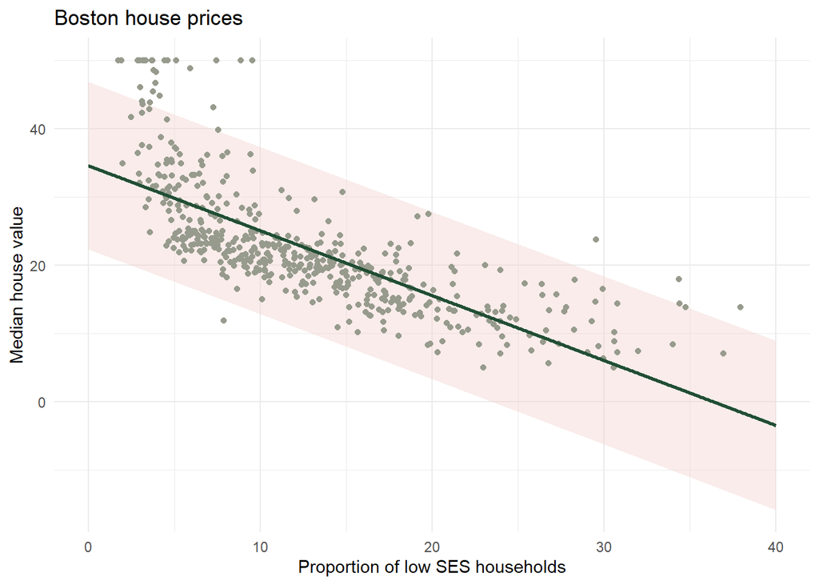

```r
Boston %>% ggplot(aes(y=medv,x=lstat))+geom_ribbon(aes(ymin=lower,ymax=upper),data=pred_int_95,fill=alpha(colour = "#EFD0CA",alpha = 0.4))+geom_point(colour="#979B8D")+geom_line(data = pred_dat,colour="#214E34",size=1)+theme_minimal()+labs(x    = "Proportion of low SES households",
       y    = "Median house value",
       title = "Boston house prices")
```

# Mean square error

### 16.Write a function called mse() that takes in two vectors: true y values and predicted y values, and which outputs the mean square error.

```r
mse <- function(y_true, y_pred) {
  mes<-round(1/length(y_true)*sum((y_true-y_pred)^2),3)
  return(mes)
}
```

###17.Make sure your mse() function works correctly by running the following code.

```r
mse(1:10, 10:1)
```

```
## [1] 33
```

### 18.Calculate the mean square error of the lm_ses model. Use the medv column as y_true and use the predict() method to generate y_pred.

```r
mse(Boston$medv,predict(lm_ses))
```

```
## [1] 38.483
```

# Train-validation-test split

Now we will use the `sample()` function to randomly select observations from the `Boston` dataset to go into a training, test, and validation set. The training set will be used to fit our model, the validation set will be used to calculate the out-of sample prediction error during model building, and the test set will be used to estimate the true out-of-sample MSE.

### 19.The `Boston` dataset has 506 observations. Use `c()` and `rep()` to create a vector with 253 times the word “train”, 152 times the word “validation”, and 101 times the word “test”. Call this vector `splits.`

```r
splits<-c(rep("train",253),rep("validation",152),rep("test",101))
head(splits)
```

```
## [1] "train" "train" "train" "train" "train" "train"
```

```r
tail(splits)
```

```
## [1] "test" "test" "test" "test" "test" "test"
```

### 20.Use the function `sample()` to randomly order this vector and add it to the Boston dataset using `mutate()`. Assign the newly created dataset to a variable called `boston_master`.

```r
Boston%<>%mutate(boston_master=sample(splits))
head(Boston)
```

```
##      crim zn indus chas   nox    rm  age    dis rad tax ptratio  black lstat
## 1 0.00632 18  2.31    0 0.538 6.575 65.2 4.0900   1 296    15.3 396.90  4.98
## 2 0.02731  0  7.07    0 0.469 6.421 78.9 4.9671   2 242    17.8 396.90  9.14
## 3 0.02729  0  7.07    0 0.469 7.185 61.1 4.9671   2 242    17.8 392.83  4.03
## 4 0.03237  0  2.18    0 0.458 6.998 45.8 6.0622   3 222    18.7 394.63  2.94
## 5 0.06905  0  2.18    0 0.458 7.147 54.2 6.0622   3 222    18.7 396.90  5.33
## 6 0.02985  0  2.18    0 0.458 6.430 58.7 6.0622   3 222    18.7 394.12  5.21
##   medv boston_master
## 1 24.0         train
## 2 21.6    validation
## 3 34.7          test
## 4 33.4         train
## 5 36.2         train
## 6 28.7         train
```

### 21.Now use `filter()` to create a training, validation, and test set from the boston_master data. Call these datasets `boston_train`, `boston_valid`, and `boston_test`

```r
boston_train<-Boston %>% filter(boston_master=="train")
boston_valid<-Boston %>% filter(boston_master=="validation")
boston_test<-Boston %>% filter(boston_master=="test")
```

### 22.Train a linear regression model called `model_1`using the training dataset. Use the formula `medv ~ lstat` like in the first lm() exercise. Use `summary()` to check that this object is as you expect.

```r
model1<-lm(data=boston_train,medv ~ lstat)
summary(model1)
```

```
##
## Call:
## lm(formula = medv ~ lstat, data = boston_train)
##
## Residuals:
##    Min     1Q Median     3Q    Max
## -10.36  -4.38  -1.19   2.13  21.94
##
## Coefficients:
##             Estimate Std. Error t value Pr(>|t|)
## (Intercept) 35.45165    0.77356   45.83   <2e-16 ***
## lstat       -0.99331    0.05486  -18.11   <2e-16 ***
## ---
## Signif. codes:  0 '***' 0.001 '**' 0.01 '*' 0.05 '.' 0.1 ' ' 1
##
## Residual standard error: 6.324 on 251 degrees of freedom
## Multiple R-squared:  0.5664, Adjusted R-squared:  0.5647
## F-statistic: 327.9 on 1 and 251 DF,  p-value: < 2.2e-16
```

### 23.Calculate the MSE with this object. Save this value as model_1_mse_train.

```r
model_1_mse_train<-mse(boston_train$medv,predict(model1))
model_1_mse_train
```

```
## [1] 39.676
```

### 24.Now calculate the MSE on the validation set and assign it to variable model_1_mse_valid. Hint: use the newdata argument in predict()

```r
pred_val<-predict(model1,newdata = boston_valid)
model_1_mse_valid<-mse(boston_valid$medv,pred_val)
model_1_mse_valid
```

```
## [1] 35.135
```

### 25.Create a second model model_2 for the train data which includes age and tax as predictors. Calculate the train and validation MSE.

```r
model_2<-lm(medv~age+tax,data=boston_train)
mse(boston_train$medv,predict(model_2))
```

```
## [1] 71.729
```

```r
mse(boston_valid$medv,predict(model_2,newdata =boston_valid ))
```

```
## [1] 54.394
```

### 26.Compare model 1 and model 2 in terms of their training and validation MSE. Which would you choose and why?

model1 has both lower training and validation MSE so I chose the one.

### 27.Calculate the test MSE for the model of your choice in the previous question. What does this number tell you?

```r
sqrt(mse(boston_test$medv,predict(model1,newdata =boston_test )))
```

```
## [1] 6.451666
```

### 28.Create a function that performs k-fold cross-validation for linear models.

```r
cross_val<-function(formula,data,k){
  stopifnot(is_formula(formula))
  stopifnot(is.data.frame(data))
  stopifnot(is.integer(as.integer(k)))

  nsize<-nrow(data)
  folds<-rep(1:k,length.out=nsize)
  dat<-data %>% mutate(folds=sample(folds))
  mse_cal<-c(rep(0,k))
  for(i in 1:k){
    val<-dat %>%filter(folds==i)
    train<-dat %>% filter(folds!=i)
    model1<-lm(data=train,formula = formula)
    name_dep<-as.character(formula[2])
    mse_cal[i]<-mse(y_true =val[[name_dep]] ,y_pred = predict(model1,newdata = val))
  }
  mean(mse_cal)

}

cross_val(medv~age+tax,Boston,5)
```

```
## [1] 64.5654
```

### 29 Use your function to perform 9-fold cross validation with a linear model with as its formula medv ~ lstat + age + tax. Compare it to a model with as formulat medv ~ lstat + I(lstat^2) + age + tax.

```r
cross_val(formula = medv ~ lstat + age + tax, data = Boston, k = 9)
```

```
## [1] 37.72711
```

```r
cross_val(formula = medv ~ lstat + I(lstat^2) + age + tax, data = Boston, k = 9)
```

```
## [1] 28.32556
```